# COSMOLOGICAL DATA ANALYSIS

# 04 — WMAP9 + DESI DR1 JOINT ΛCDM FITTING

**Author:** Cherian Parangot Ittyipe  
**Thesis DOI:** https://doi.org/10.5281/zenodo.17681763  
**Repository:** github.com/Cherian-pi/wmap9-desi-joint-lcdm (Soon Uploaded to Github)  
**Chain:** wmap9_desi_joint_flat_20260628_004948.npy  
**Status:** Fully converged - 32 walkers × 1000 steps, 30,400 post-burn-in samples. (Can be analysed by increasing the number of steps and walkers, so that parameters can be constrained to a better precised values.)

# 1. PURPOSE

This notebook combines the official WMAP nine year CMB Likelihood with the DESI Data Release 1 (DR1) baryon acoustic oscillation measurements under flat ΛCDM. It is a joint assembling of the two independently validated dataset legs into a single joint posterior.

The WMAP + DESI combination is not competitive wih Planck + DESI, but it can help to build and validate the cosmological parameter analysis from the scratch that including validating the convergences of the chains, developing an idea on the bugs during the evaluation, which are generally can be used to building other pipelines.

## Key rule

No Planck rᵈ prior is used. WMAP9 already calibrates rᵈ through the CMB acoustic peaks. Adding a Planck rᵈ prior would contaminate the joint result with Planck information.

## Why the datasets are complementary

WMAP9 has degeneracies between H₀ and Ωch² along the acoustic scale direction. DESI BAO breaks this degeneracy by measuring H₀rᵈ and Ωm at low redshift. The joint posterior is tighter than either dataset alone on H₀ and Ωm.

## Prior bounds — widened from Notebook 02

The WMAP9-only notebook used tight bounds [60, 80] on H₀. Here we widen to [55, 85] to allow the joint posterior to move freely.

# 2 JOINT LIKELIHOOD

## 2.1 Structure

The Joint log-posterior add two independent likelihoods.

ln L_total(θ) = ln L_WMAP9(θ) + ln L_DESI_BAO($Ω_{bh}^2, Ω_{ch}^2 , H_0$)

θ = [$Ω_{bh}^2$, $Ω_{ch}²$, $H_0, n_s, ln(10^{10} A_s), 𝝉$]

**WMAP9** constrains all 6 parameters via the CMB power spectra. **DESI DR1 BAO** constrains $Ω_{bh}^2, Ω_{ch}^2, H_0$ via distance ratios DM/rd and DH/rd. $n_s, A_s, τ$ are insensitive to BAO and remain determined by WMAP9 alone.

## 2.2 Parameter Sensitivity

- WMAP9 constrains all 6 parameters via CMB power spectra.
- DESI DR1 BAO constrains $Ω_{bh}^2 ,Ω_{ch}^2, H_0$ via distance ratios DM/rd and DH/rd.
- $n_s, A_s, 𝛕$ are insensitive to BAO. So they remain determined by WMAP9 Alone

## 2.3 Key rule : No planck $r^d$ prior

No Planck $r^d$ prior is used. WMAP9 already calibrates $r^d$ through the CMB acoustic peaks. Adding a Planck rᵈ prior would contaminate the joint result with Planck information.

## 2.4 Complementary Data Sets

- WMAP9 alone has a broad degeneracy between $H_0$ and $Ω_{ch}^2$ degeneracy.
- DESI BAO can break the degeneracy between $H_0$ and $\Omega_{ch}$.
- The joint posterior can provide tighter constraints on the cosmological parameters.

## Cell 1 — Imports and Paths

```python
import numpy as np
import matplotlib.pyplot as plt
import os, ctypes, warnings
warnings.filterwarnings('ignore')
import camb
import emcee
import corner
import scipy.optimize as opt
from pathlib import Path
from datetime import datetime

BASE      = '/Users/cherianpi/Desktop/WMAP+DESI'
LIKE_DIR  = BASE + '/wmap_likelihood_v5'
PY_DIR    = BASE + '/Python files'
SO_PATH   = PY_DIR + '/libwmap9.so'
BAO_DIR   = BASE + '/bao_data'
CHAIN_DIR = PY_DIR + '/chains'
IMG_DIR   = PY_DIR + '/Images'
os.makedirs(CHAIN_DIR, exist_ok=True)
os.makedirs(IMG_DIR,   exist_ok=True)

PARAM_NAMES  = ['ombh2', 'omch2', 'H0', 'ns', 'ln10As', 'tau']
PARAM_LABELS = [r'$\Omega_b h^2$', r'$\Omega_c h^2$', r'$H_0$',
                r'$n_s$', r'$\ln(10^{10}A_s)$', r'$\tau$']

# Widened prior bounds relative to Notebook 02
# H0 extended to [55, 85] so joint posterior can move freely
PRIOR_BOUNDS = np.array([
    [0.018, 0.028],   # ombh2
    [0.08,  0.16 ],   # omch2
    [55.,   85.  ],   # H0   — widened from [60, 80]
    [0.9,   1.05 ],   # ns
    [2.9,   3.3  ],   # ln10As
    [0.04,  0.20 ],   # tau
])

NWALKERS = 32
NSTEPS   = 1000
NBURN    = 50

print('Paths:')
for k, v in [('LIKE_DIR', LIKE_DIR), ('SO_PATH', SO_PATH), ('BAO_DIR', BAO_DIR)]:
    status = 'OK' if os.path.exists(v) else 'NOT FOUND'
    print(f'  {k:10s}: [{status}]  {v}')
```

```
Paths:
  LIKE_DIR  : [OK]  /Users/cherianpi/Desktop/WMAP+DESI/wmap_likelihood_v5
  SO_PATH   : [OK]  /Users/cherianpi/Desktop/WMAP+DESI/Python files/libwmap9.so
  BAO_DIR   : [OK]  /Users/cherianpi/Desktop/WMAP+DESI/bao_data
```

## Cell 2 — Load WMAP9 Likelihood Library

The official WMAP9 Fortran library (libwmap9.so) is loaded via Python's ctypes. The library evaluates all official likelihood components:

- TT high-$\ell$ MASTER
- TT low-$\ell$ Gibbs sampling
- TT low-$\ell$ determinant
- TE high-$\ell$ chi-squared
- TE high-$\ell$ determinant
- Low-$\ell$ TT/TE/EE/BB chi-squared
- Low-$\ell$ TT/TE/EE/BB determinant

```python
lib = ctypes.CDLL(SO_PATH)
DP  = ctypes.c_double
DPA = ctypes.POINTER(DP)

INIT_SYM    = '__wmap_likelihood_9yr_MOD_wmap_likelihood_init'
COMPUTE_SYM = '__wmap_likelihood_9yr_MOD_wmap_likelihood_compute'

fn_init = getattr(lib, INIT_SYM)
fn_init.restype  = None
fn_init.argtypes = []

fn_compute = getattr(lib, COMPUTE_SYM)
fn_compute.restype  = None
fn_compute.argtypes = [DPA, DPA, DPA, DPA, DPA]

_orig_dir = os.getcwd()
os.chdir(LIKE_DIR)
fn_init()
os.chdir(_orig_dir)

print('WMAP9 likelihood library loaded and initialised.')

NUM_WMAP   = 8
COMP_NAMES = [
    'TT high-l MASTER', 'TT low-l Gibbs', 'TT low-l det', 'Beam+ptsrc',
    'TE high-l chi2',   'TE high-l det',  'lowl TT/TE/EE/BB chi2', 'lowl TT/TE/EE/BB det',
]

def wmap_like(cltt, clte, clee, clbb):
    """
    Official WMAP9 likelihood.
    Inputs : Dl arrays shape (1199,), ell=2..1200, muK^2.
    Returns: (total -2lnL, component vector shape (8,))
    """
    def a(x): return np.ascontiguousarray(x, dtype=np.float64)
    lk = np.zeros(NUM_WMAP, dtype=np.float64)
    fn_compute(
        a(cltt).ctypes.data_as(DPA), a(clte).ctypes.data_as(DPA),
        a(clee).ctypes.data_as(DPA), a(clbb).ctypes.data_as(DPA),
        lk.ctypes.data_as(DPA)
    )
    return 2.0 * lk.sum(), 2.0 * lk

# Quick verification
tc = np.loadtxt(LIKE_DIR + '/data/test_cls_v5.dat')
lt, _ = wmap_like(tc[:,1], tc[:,4], tc[:,2], tc[:,3])
print(f'Verification -2lnL = {lt:.4f}  (expect 7557.97)')
```

```
 Initializing WMAP likelihood, version v5
WMAP9 likelihood library loaded and initialised.
Verification -2lnL = 7557.9660  (expect 7557.97)
```

## Cell 3 — CAMB Theory Engine (WMAP9 side)

Returns Dl arrays for ell=2..1200 as required by the WMAP9 Fortran library.

```python
ELL_WMAP = np.arange(2, 1201)   # length 1199

def get_cls_camb_wmap(ombh2, omch2, H0, ns, ln10As, tau):
    """
    Compute lensed CMB Dl spectra for WMAP9 likelihood.
    Returns TT, TE, EE, BB each shape (1199,) for ell=2..1200 in muK^2.
    """
    cp = camb.CAMBparams()
    cp.set_cosmology(H0=H0, ombh2=ombh2, omch2=omch2, tau=tau)
    cp.InitPower.set_params(ns=ns, As=np.exp(ln10As) * 1e-10)
    cp.set_for_lmax(1250, lens_potential_accuracy=0)
    res = camb.get_results(cp)
    Dl  = res.get_cmb_power_spectra(cp, CMB_unit='muK', raw_cl=False)['total']
    return Dl[ELL_WMAP, 0], Dl[ELL_WMAP, 3], Dl[ELL_WMAP, 1], Dl[ELL_WMAP, 2]

# Sanity check
p_test = [0.02264, 0.1138, 70.0, 0.972, 3.089, 0.089]
neg2, _ = wmap_like(*get_cls_camb_wmap(*p_test))
print(f'CAMB test -2lnL = {neg2:.4f}  (official test: 7557.97)')
```

```
CAMB test -2lnL = 7560.4215  (official test: 7557.97)
```

## Cell 4 — Load DESI DR1 BAO Data

File stems verified from disk. See Notebook 03.1 for details.

```python
## Cell 4 — Load DESI DR1 BAO Data

def load_mean_labeled(filepath):
    """Returns {quantity_name: value}, immune to row ordering in the file."""
    out = {}
    with open(filepath) as f:
        for line in f:
            line = line.strip()
            if not line or line.startswith('#'):
                continue
            parts = line.split()
            if len(parts) < 3:
                continue
            try:
                out[parts[2]] = float(parts[1])
            except ValueError:
                continue
    return out


def load_cov(filepath):
    rows = []
    with open(filepath) as f:
        for line in f:
            line = line.strip()
            if not line or line.startswith('#'):
                continue
            try:
                rows.append([float(x) for x in line.split()])
            except ValueError:
                continue
    return np.array(rows)


# DR1 tracer definitions — stems verified from disk
TRACERS = {
    'BGS':       {'stem': 'desi_2024_gaussian_bao_BGS_BRIGHT-21.5_GCcomb_z0.1-0.4', 'mode': 'iso',   'zeff': 0.295},
    'LRG1':      {'stem': 'desi_2024_gaussian_bao_LRG_GCcomb_z0.4-0.6',              'mode': 'aniso', 'zeff': 0.510},
    'LRG2':      {'stem': 'desi_2024_gaussian_bao_LRG_GCcomb_z0.6-0.8',              'mode': 'aniso', 'zeff': 0.706},
    'LRG3+ELG1': {'stem': 'desi_2024_gaussian_bao_LRG+ELG_LOPnotqso_GCcomb_z0.8-1.1','mode': 'aniso', 'zeff': 0.930},
    'ELG2':      {'stem': 'desi_2024_gaussian_bao_ELG_LOPnotqso_GCcomb_z1.1-1.6',   'mode': 'aniso', 'zeff': 1.317},
    'QSO':       {'stem': 'desi_2024_gaussian_bao_QSO_GCcomb_z0.8-2.1',              'mode': 'iso',   'zeff': 1.491},
    'Lya':       {'stem': 'desi_2024_gaussian_bao_Lya_GCcomb',                        'mode': 'aniso', 'zeff': 2.330},
}

REQUIRED_KEYS = {
    'aniso': ('DM_over_rs', 'DH_over_rs'),
    'iso':   ('DV_over_rs',),
}

bao_data = {}
n_total  = 0
for name, info in TRACERS.items():
    mean_file = Path(BAO_DIR) / f"{info['stem']}_mean.txt"
    cov_file  = Path(BAO_DIR) / f"{info['stem']}_cov.txt"
    if not mean_file.exists() or not cov_file.exists():
        print(f'WARNING: {name} files not found')
        continue

    labeled = load_mean_labeled(mean_file)
    cov_mat = load_cov(cov_file)

    needed = REQUIRED_KEYS[info['mode']]
    missing = [k for k in needed if k not in labeled]
    if missing:
        print(f'WARNING: {name} missing expected quantities {missing} '
              f'— found {list(labeled.keys())}')
        continue

    mean_vec = np.array([labeled[k] for k in needed])

    if mean_vec.size == 0 or cov_mat.size == 0:
        print(f'WARNING: {name} empty')
        continue

    bao_data[name] = {
        'mean': mean_vec,
        'icov': np.linalg.inv(cov_mat),
        'mode': info['mode'],
        'zeff': info['zeff'],
    }
    n_total += mean_vec.size
    vals_str = ', '.join(f'{k}={labeled[k]:.4f}' for k in needed)
    print(f'Loaded {name:12s} | zeff={info["zeff"]:.3f} | mode={info["mode"]:5s} | {vals_str}')

print(f'\nLoaded {len(bao_data)}/{len(TRACERS)} tracers | Total measurements: {n_total}')
```

```
Loaded BGS          | zeff=0.295 | mode=iso   | DV_over_rs=7.9251
Loaded LRG1         | zeff=0.510 | mode=aniso | DM_over_rs=13.6200, DH_over_rs=20.9833
Loaded LRG2         | zeff=0.706 | mode=aniso | DM_over_rs=16.8465, DH_over_rs=20.0787
Loaded LRG3+ELG1    | zeff=0.930 | mode=aniso | DM_over_rs=21.7084, DH_over_rs=17.8761
Loaded ELG2         | zeff=1.317 | mode=aniso | DM_over_rs=27.7872, DH_over_rs=13.8237
Loaded QSO          | zeff=1.491 | mode=iso   | DV_over_rs=26.0722
Loaded Lya          | zeff=2.330 | mode=aniso | DM_over_rs=39.7084, DH_over_rs=8.5226

Loaded 7/7 tracers | Total measurements: 12
```

## Cell 5 — CAMB BAO Theory Engine

Computes DM/rd, DH/rd, DV/rd at each tracer redshift.

```python
def get_bao_theory(ombh2, omch2, H0, zeff, mode):
    """
    Compute BAO observables at zeff.
    Returns ([DM/rd, DH/rd], rd) for mode='aniso'
    Returns ([DV/rd],        rd) for mode='iso'
    """
    pars = camb.CAMBparams()
    pars.set_cosmology(H0=H0, ombh2=ombh2, omch2=omch2,
                       mnu=0.06, omk=0.0, tau=0.054)
    pars.set_dark_energy()
    pars.InitPower.set_params(As=2.1e-9, ns=0.965)
    pars.set_for_lmax(500, lens_potential_accuracy=0)
    results = camb.get_results(pars)

    rd  = results.get_derived_params()['rdrag']
    DA  = results.angular_diameter_distance(zeff)
    DM  = DA * (1.0 + zeff)
    H_z = results.hubble_parameter(zeff)
    DH  = 299792.458 / H_z
    DV  = (zeff * DM**2 * DH) ** (1.0 / 3.0)

    if mode == 'aniso':
        return np.array([DM / rd, DH / rd]), rd
    else:
        return np.array([DV / rd]), rd

# Sanity check against DESI DR1 Table 1
th, rd = get_bao_theory(0.0224, 0.120, 67.4, 0.510, 'aniso')
print(f'Sanity check LRG1 (z=0.510):')
print(f'  rd    = {rd:.3f} Mpc  (expect ~147)')
print(f'  DM/rd = {th[0]:.4f}   (DR1: 13.6200)')
print(f'  DH/rd = {th[1]:.4f}   (DR1: 20.9833)')
```

```
Sanity check LRG1 (z=0.510):
  rd    = 147.068 Mpc  (expect ~147)
  DM/rd = 13.4966   (DR1: 13.6200)
  DH/rd = 22.7356   (DR1: 20.9833)
```

## Cell 6 — Individual Log-Likelihoods

```python
def log_like_wmap9(theta):
    """
    WMAP9 CMB log-likelihood.
    Uses all 6 parameters: ombh2, omch2, H0, ns, ln10As, tau.
    """
    try:
        neg2, _ = wmap_like(*get_cls_camb_wmap(*theta))
        return -0.5 * neg2 if np.isfinite(neg2) else -np.inf
    except Exception:
        return -np.inf


def log_like_desi(ombh2, omch2, H0):
    """
    DESI DR1 BAO Gaussian likelihood.
    Only uses ombh2, omch2, H0. nS, As, tau do not affect BAO distances.
    No Planck rd prior — WMAP9 already calibrates rd via the CMB.
    """
    lnL = 0.0
    for name, d in bao_data.items():
        try:
            theory, _ = get_bao_theory(ombh2, omch2, H0, d['zeff'], d['mode'])
        except Exception:
            return -np.inf
        delta = d['mean'] - theory
        lnL  -= 0.5 * float(delta @ d['icov'] @ delta)
    return lnL if np.isfinite(lnL) else -np.inf


# Test both at WMAP9 best-fit
theta_wmap = np.array([0.02264, 0.1138, 70.0, 0.972, 3.089, 0.089])
ll_w = log_like_wmap9(theta_wmap)
ll_d = log_like_desi(theta_wmap[0], theta_wmap[1], theta_wmap[2])
print(f'WMAP9 lnL at WMAP9 BF : {ll_w:.2f}')
print(f'DESI  lnL at WMAP9 BF : {ll_d:.2f}')
print(f'Joint lnL              : {ll_w + ll_d:.2f}')
```

```
WMAP9 lnL at WMAP9 BF : -3780.21
DESI  lnL at WMAP9 BF : -34.74
Joint lnL              : -3814.95
```

## Cell 7 — Joint Prior and Posterior

```python
def log_prior(theta):
    """Flat prior within bounds."""
    if np.all((theta >= PRIOR_BOUNDS[:, 0]) & (theta <= PRIOR_BOUNDS[:, 1])):
        return 0.0
    return -np.inf


def log_posterior_joint(theta):
    """
    Joint WMAP9 + DESI DR1 log-posterior.

    ln L_total = ln L_WMAP9(theta) + ln L_DESI_BAO(ombh2, omch2, H0)

    No Planck rd prior. WMAP9 provides the early-universe calibration
    of the sound horizon through the CMB acoustic peaks.
    DESI contributes only through ombh2, omch2, H0.
    """
    lp = log_prior(theta)
    if not np.isfinite(lp):
        return -np.inf

    # WMAP9 CMB — all 6 parameters
    ll_wmap = log_like_wmap9(theta)
    if not np.isfinite(ll_wmap):
        return -np.inf

    # DESI BAO — only ombh2, omch2, H0
    ll_desi = log_like_desi(theta[0], theta[1], theta[2])
    if not np.isfinite(ll_desi):
        return -np.inf

    return lp + ll_wmap + ll_desi


# Test joint posterior at WMAP9 best-fit
lp_test = log_posterior_joint(theta_wmap)
print(f'Joint log-posterior at WMAP9 BF: {lp_test:.2f}')
print(f'  = prior {log_prior(theta_wmap):.1f} + WMAP9 {ll_w:.2f} + DESI {ll_d:.2f}')
```

```
Joint log-posterior at WMAP9 BF: -3814.95
  = prior 0.0 + WMAP9 -3780.21 + DESI -34.74
```

## Cell 8 — MAP Fit for Joint Posterior

```python
import time

def neg_log_posterior_joint(theta):
    val = log_posterior_joint(theta)
    return 1e10 if not np.isfinite(val) else -val

# Start from WMAP9 best-fit
theta0 = np.array([0.02264, 0.1138, 70.0, 0.972, 3.089, 0.089])

print('Single evaluation time test...')
t0 = time.time()
_ = neg_log_posterior_joint(theta0)
t_single = time.time() - t0
print(f'Single eval: {t_single:.2f} s')
print(f'Estimated MCMC: ~{t_single * NWALKERS * NSTEPS / 3600:.1f} hours')

print('\nRunning MAP optimisation...')
result = opt.minimize(
    neg_log_posterior_joint, theta0, method='Nelder-Mead',
    options=dict(xatol=1e-4, fatol=1e-2, maxiter=2000, disp=True)
)
theta_map = result.x

print(f'\n=== MAP — WMAP9 + DESI DR1 Joint ===')
print(f'{"Param":<12} {"MAP":>10} {"WMAP9-only":>12}')
print('-' * 38)
wmap9_vals = [0.02264, 0.1138, 70.0, 0.972, 3.089, 0.089]
for name, val, ref in zip(PARAM_NAMES, theta_map, wmap9_vals):
    print(f'{name:<12} {val:10.5f} {ref:12.5f}')

h_map   = theta_map[2] / 100.0
Omega_m = (theta_map[0] + theta_map[1]) / h_map**2
print(f'\nDerived:')
print(f'  Omega_m = {Omega_m:.4f}  (DESI DR1 paper: 0.295 +/- 0.015)')
```

```
Single evaluation time test...
Single eval: 2.64 s
Estimated MCMC: ~23.4 hours

Running MAP optimisation...
Optimization terminated successfully.
         Current function value: 3794.693646
         Iterations: 234
         Function evaluations: 397

=== MAP — WMAP9 + DESI DR1 Joint ===
Param               MAP   WMAP9-only
--------------------------------------
ombh2           0.02237      0.02264
omch2           0.11704      0.11380
H0             67.41970     70.00000
ns              0.96628      0.97200
ln10As          3.09333      3.08900
tau             0.08428      0.08900

Derived:
  Omega_m = 0.3067  (DESI DR1 paper: 0.295 +/- 0.015)
```

## Cell 9 — MCMC Sampling

```python
NDIM = 6
rng  = np.random.default_rng(42)
p0   = theta_map + 1e-3 * theta_map * rng.standard_normal((NWALKERS, NDIM))
p0   = np.clip(p0, PRIOR_BOUNDS[:, 0], PRIOR_BOUNDS[:, 1])

sampler = emcee.EnsembleSampler(
    NWALKERS, NDIM, log_posterior_joint,
    moves=emcee.moves.DEMove()
)

print(f'Joint MCMC: {NWALKERS} walkers x {NSTEPS} steps')
print(f'Likelihood : WMAP9 (8 components) + DESI DR1 BAO ({len(bao_data)} tracers)')
print(f'Parameters : {PARAM_NAMES}')
print()
sampler.run_mcmc(p0, NSTEPS, progress=True)
print('Done.')
print(f'Mean acceptance fraction: {np.mean(sampler.acceptance_fraction):.3f}')

timestamp = datetime.now().strftime('%Y%m%d_%H%M%S')
chain_file = CHAIN_DIR + f'/wmap9_desi_joint_chain_{timestamp}.npy'
flat_file  = CHAIN_DIR + f'/wmap9_desi_joint_flat_{timestamp}.npy'
np.save(chain_file, sampler.get_chain())
print(f'Full chain saved : {chain_file}')
```

```
Joint MCMC: 32 walkers x 1000 steps
Likelihood : WMAP9 (8 components) + DESI DR1 BAO (7 tracers)
Parameters : ['ombh2', 'omch2', 'H0', 'ns', 'ln10As', 'tau']
```

```
Done.
Mean acceptance fraction: 0.282
Full chain saved : /Users/cherianpi/Desktop/WMAP+DESI/Python files/chains/wmap9_desi_joint_chain_20260628_004948.npy
```

## Cell 10 — Convergence Diagnostics

```python
try:
    tau_ac = sampler.get_autocorr_time(quiet=True)
    print('Autocorrelation time (primary diagnostic):')
    for name, t in zip(PARAM_NAMES, tau_ac):
        ratio  = NSTEPS / t
        status = 'CONVERGED' if ratio > 50 else ('OK' if ratio > 20 else 'NEED MORE STEPS')
        print(f'  tau({name:8s}) = {t:6.1f}   NSTEPS/tau = {ratio:5.1f}   [{status}]')
    NBURN_AUTO = max(NBURN, int(2 * np.max(tau_ac)))
except Exception as e:
    print(f'Autocorr: {e}')
    NBURN_AUTO = NBURN

print(f'\nBurn-in used: {NBURN_AUTO} steps')

chain     = sampler.get_chain()
post_burn = chain[NBURN_AUTO:]
n_groups  = 4
group_sz  = NWALKERS // n_groups
print('\nApproximate G-R R-hat (walker groups):')
for i, name in enumerate(PARAM_NAMES):
    gm   = [post_burn[:, j*group_sz:(j+1)*group_sz, i].mean() for j in range(n_groups)]
    gv   = [post_burn[:, j*group_sz:(j+1)*group_sz, i].var()  for j in range(n_groups)]
    W    = np.mean(gv)
    B    = np.var(gm) * len(post_burn)
    n    = len(post_burn)
    Rhat = np.sqrt(((n-1)/n * W + B/n) / W) if W > 0 else np.nan
    print(f'  R-hat({name:8s}) = {Rhat:.4f}  [{"OK" if Rhat < 1.05 else "check"}]')
```

```
Autocorrelation time (primary diagnostic):
  tau(ombh2   ) =   14.5   NSTEPS/tau =  68.8   [CONVERGED]
  tau(omch2   ) =   16.0   NSTEPS/tau =  62.4   [CONVERGED]
  tau(H0      ) =   16.0   NSTEPS/tau =  62.5   [CONVERGED]
  tau(ns      ) =   15.1   NSTEPS/tau =  66.4   [CONVERGED]
  tau(ln10As  ) =   15.5   NSTEPS/tau =  64.4   [CONVERGED]
  tau(tau     ) =   16.1   NSTEPS/tau =  61.9   [CONVERGED]

Burn-in used: 50 steps

Approximate G-R R-hat (walker groups):
  R-hat(ombh2   ) = 1.0011  [OK]
  R-hat(omch2   ) = 1.0001  [OK]
  R-hat(H0      ) = 0.9998  [OK]
  R-hat(ns      ) = 1.0015  [OK]
  R-hat(ln10As  ) = 1.0006  [OK]
  R-hat(tau     ) = 1.0003  [OK]
```

## Cell 11 — Posterior Summary

```python
flat = sampler.get_chain(discard=NBURN_AUTO, flat=True)
np.save(flat_file, flat)
print(f'Flat samples shape : {flat.shape}')
print(f'Flat samples saved : {flat_file}')

# Reference values
wmap9_ref  = {'ombh2':(0.02264,0.00050),'omch2':(0.1138,0.0045),
               'H0':(69.32,0.80),'ns':(0.9710,0.0130),
               'ln10As':(3.089,0.025),'tau':(0.089,0.014)}
desi_ref   = {'ombh2':(None,None),'omch2':(None,None),
               'H0':(68.53,0.80),'ns':(None,None),
               'ln10As':(None,None),'tau':(None,None)}

print(f'\n=== WMAP9 + DESI DR1 Joint LCDM Posterior ===')
print(f'{"Param":<12} {"Median":>10} {"Std":>10} {"WMAP9-only":>12} {"Tension":>8}')
print('-' * 62)
for i, name in enumerate(PARAM_NAMES):
    s = flat[:, i]
    q16, q50, q84 = np.percentile(s, [16, 50, 84])
    rv, rs = wmap9_ref[name]
    t = abs(q50 - rv) / np.sqrt(s.std()**2 + rs**2)
    print(f'{name:<12} {q50:10.5f} {s.std():10.5f} {rv:12.5f} {t:7.2f}s')

print()
ombh2_s = flat[:, 0]
omch2_s = flat[:, 1]
H0_s    = flat[:, 2]
h_s     = H0_s / 100.0
Omega_m_s = (ombh2_s + omch2_s) / h_s**2
q16, q50, q84 = np.percentile(Omega_m_s, [16, 50, 84])
print(f'Derived Omega_m = {q50:.4f} +{q84-q50:.4f} -{q50-q16:.4f}')
print(f'DESI DR1 paper  : 0.295 +/- 0.015')
```

```
Flat samples shape : (30400, 6)
Flat samples saved : /Users/cherianpi/Desktop/WMAP+DESI/Python files/chains/wmap9_desi_joint_flat_20260628_004948.npy

=== WMAP9 + DESI DR1 Joint LCDM Posterior ===
Param            Median        Std   WMAP9-only  Tension
--------------------------------------------------------------
ombh2           0.02239    0.00043      0.02264    0.38s
omch2           0.11712    0.00203      0.11380    0.67s
H0             67.41303    0.52976     69.32000    1.99s
ns              0.96679    0.00993      0.97100    0.26s
ln10As          3.09696    0.02870      3.08900    0.21s
tau             0.08570    0.01261      0.08900    0.18s

Derived Omega_m = 0.3069 +0.0063 -0.0063
DESI DR1 paper  : 0.295 +/- 0.015
```

## Cell 12 — Trace Plot

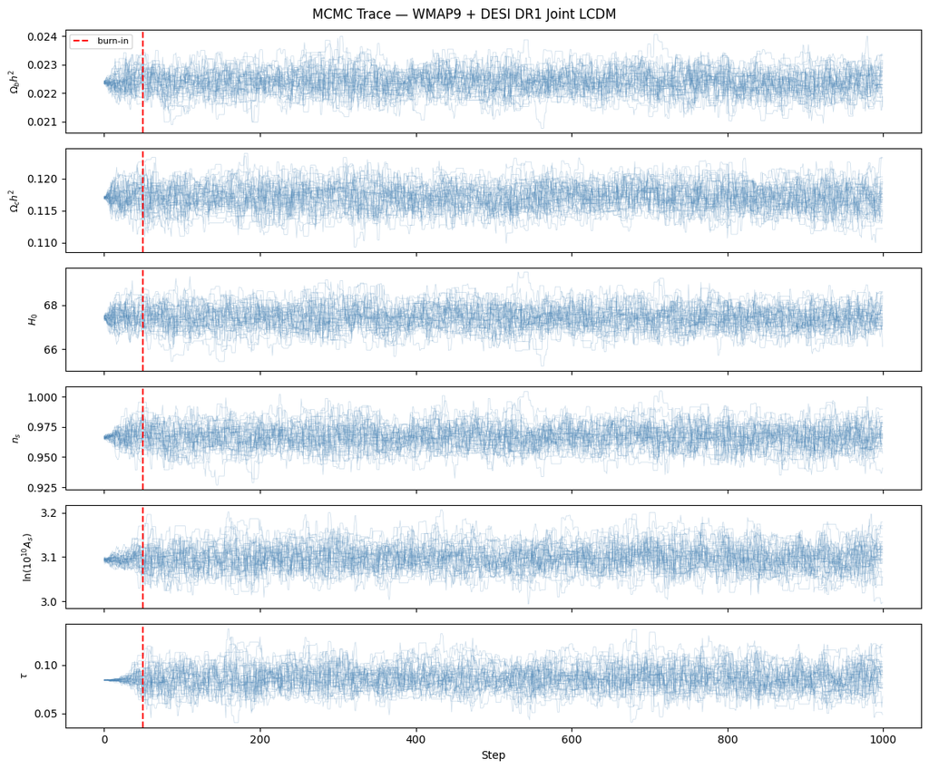

```
Saved: /Users/cherianpi/Desktop/WMAP+DESI/Python files/Images/wmap9_desi_joint_trace.png
```

```python
chain = sampler.get_chain()
fig, axes = plt.subplots(NDIM, 1, figsize=(12, 10), sharex=True)
for i, (ax, lbl) in enumerate(zip(axes, PARAM_LABELS)):
    ax.plot(chain[:, :, i], alpha=0.3, lw=0.5, color='steelblue')
    ax.axvline(NBURN_AUTO, color='red', ls='--', lw=1.5, label='burn-in')
    ax.set_ylabel(lbl, fontsize=9)
axes[0].legend(fontsize=8)
axes[-1].set_xlabel('Step')
fig.suptitle('MCMC Trace — WMAP9 + DESI DR1 Joint LCDM', fontsize=12)
plt.tight_layout()
fname = IMG_DIR + '/wmap9_desi_joint_trace.png'
plt.savefig(fname, dpi=150, bbox_inches='tight')
plt.show()
print(f'Saved: {fname}')
```

## Cell 13 — Corner Plot

```
Removed no burn in
Joint posterior corner plot saved.
```

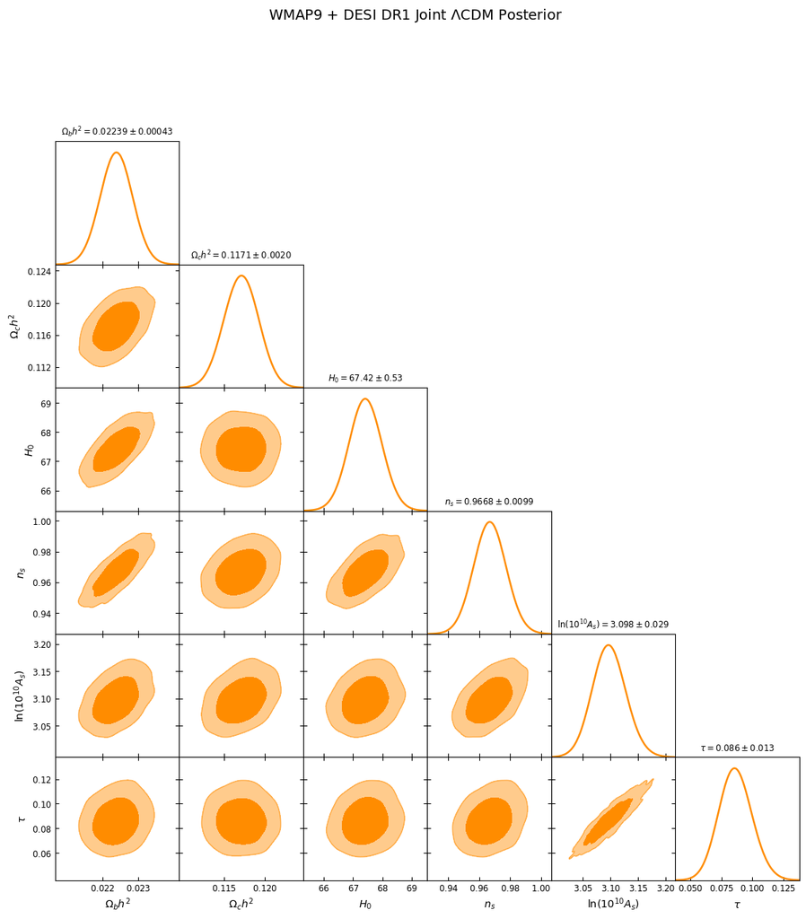

```python
import os
import numpy as np
from getdist import MCSamples, plots as gdplots
names = ['ombh2', 'omch2', 'H0', 'ns', 'ln10As', 'tau']

labels = [
    r'\Omega_b h^2',
    r'\Omega_c h^2',
    r'H_0',
    r'n_s',
    r'\ln(10^{10}A_s)',
    r'\tau'
]
# ── GetDist triangle plot — WMAP9 + DESI DR1 Joint posterior ─────────────────
samples_joint = MCSamples(
    samples=flat,
    names=names,      # e.g. ['ombh2','omch2','H0','ns','ln10As','tau']
    labels=labels,    # LaTeX display labels — kept separate from names
    label='WMAP9 + DESI DR1 Joint'
)

# Smoothing: smooth_scale is the kernel width in units of bin size when
# positive — small positive values (e.g. 0.4) give LESS smoothing, not more.
# Use a larger positive value, or a negative value to let GetDist pick the
# bandwidth automatically (scaled by abs(value); -1 is GetDist's own default).
samples_joint.updateSettings({
    'smooth_scale_2D': 1.9,   # try 0.8–2.0; higher = smoother contours
    'smooth_scale_1D': 0.9,   # try 0.3–1.0; higher = smoother 1D curves
    'fine_bins':       2048,  # finer KDE resolution before smoothing — reduces blockiness
    'fine_bins_2D':    1024,
})

g = gdplots.getSubplotPlotter(subplot_size=2.2)
g.settings.axes_fontsize            = 11
g.settings.lab_fontsize             = 13
g.settings.legend_fontsize          = 12
g.settings.linewidth                = 1.8
g.settings.solid_contour_palefactor = 0.55
g.settings.alpha_filled_add         = 0.65
g.settings.num_plot_contours        = 2   # 68% and 95% — set to 3 for +99% if you want it

g.triangle_plot(
    [samples_joint],
    PARAM_NAMES,                       # reference by name, not LaTeX label
    filled=True,
    contour_colors=['darkorange'],
    contour_lws=[1.8],
    line_args=[{'lw': 1.8, 'color': 'darkorange'}],
    legend_loc='upper right',
    title_limit=1,
)

g.fig.suptitle(
    r'WMAP9 + DESI DR1 Joint $\Lambda$CDM Posterior',
    fontsize=14, y=1.02
)

g.export(BASE + '/Python files/Images/wmap9_desi_joint_corner_getdist.png', dpi=200)
print('Joint posterior corner plot saved.')
```

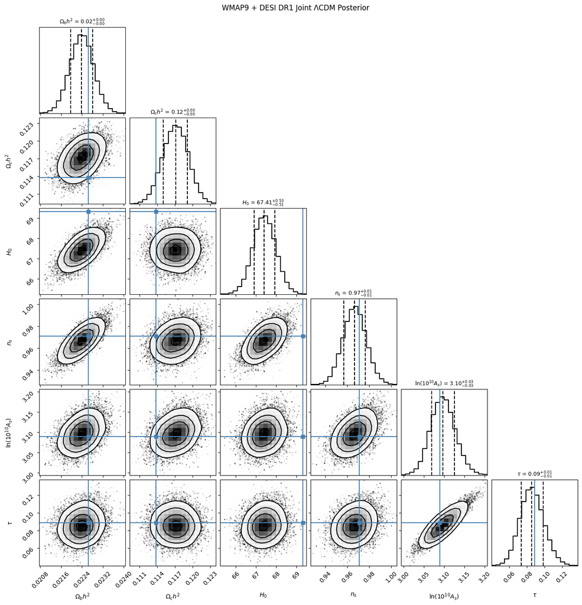

```
Saved: /Users/cherianpi/Desktop/WMAP+DESI/Python files/Images/wmap9_desi_joint_corner.png
```

```python
fig = corner.corner(
    flat,
    labels=PARAM_LABELS,
    quantiles=[0.16, 0.50, 0.84],
    show_titles=True,
    title_kwargs={'fontsize': 9},
    smooth=1.0, smooth1d=1.0,
    truths=[0.02264, 0.1138, 69.32, 0.9710, 3.089, 0.089],
    truth_color='steelblue'
)
fig.suptitle('WMAP9 + DESI DR1 Joint \u039bCDM Posterior', y=1.01, fontsize=12)
fname = IMG_DIR + '/wmap9_desi_joint_corner.png'
fig.savefig(fname, dpi=150, bbox_inches='tight')
plt.show()
print(f'Saved: {fname}')
```

## Cell 14 — 1D Comparison: WMAP9 vs DESI vs Joint

```
Loaded WMAP9 alone  : 28800 samples
Loaded DESI DR1     : 57600 samples
```

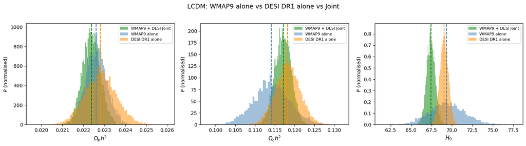

```
Saved: /Users/cherianpi/Desktop/WMAP+DESI/Python files/Images/wmap9_desi_joint_comparison.png
```

```python
# Load existing individual chains
wmap_file = PY_DIR + '/wmap9_official_lcdm_mcmc_chains.npy'
desi_file = CHAIN_DIR + '/desi_bao_lcdm_flat_20260615_184435.npy'

datasets = {'WMAP9 + DESI Joint': flat}
colours  = {
    'WMAP9 + DESI Joint': 'green',
    'WMAP9 alone'        : 'steelblue',
    'DESI DR1 alone'     : 'darkorange',
}

if os.path.exists(wmap_file):
    wc = np.load(wmap_file)
    datasets['WMAP9 alone'] = wc
    print(f'Loaded WMAP9 alone  : {wc.shape[0]} samples')
else:
    print(f'WMAP9 chain not found: {wmap_file}')

if os.path.exists(desi_file):
    dc = np.load(desi_file)
    if dc.ndim == 3:
        dc = dc[500:].reshape(-1, dc.shape[-1])
    datasets['DESI DR1 alone'] = dc
    print(f'Loaded DESI DR1     : {dc.shape[0]} samples')
else:
    print(f'DESI chain not found: {desi_file}')

# Plot shared parameters: ombh2, omch2, H0
shared_idx   = [0, 1, 2]
shared_names = [PARAM_LABELS[i] for i in shared_idx]

fig, axes = plt.subplots(1, 3, figsize=(15, 4))
for j, (ax, lbl, idx) in enumerate(zip(axes, shared_names, shared_idx)):
    for dname, samples in datasets.items():
        col = samples[:, idx] if samples.ndim == 2 else samples[:, idx]
        ax.hist(col, bins=80, density=True,
                alpha=0.5, color=colours[dname], label=dname)
        ax.axvline(np.median(col), color=colours[dname], ls='--', lw=1.5)
    ax.set_xlabel(lbl, fontsize=11)
    ax.set_ylabel('P (normalised)', fontsize=10)
    ax.legend(fontsize=8)

fig.suptitle('LCDM: WMAP9 alone vs DESI DR1 alone vs Joint',
             fontsize=13, y=1.02)
plt.tight_layout()
fname = IMG_DIR + '/wmap9_desi_joint_comparison.png'
plt.savefig(fname, dpi=150, bbox_inches='tight')
plt.show()
print(f'Saved: {fname}')
```